# tmpkcnt19ak

**GAUSSIAN NAIVE BAYES CLASSIFIERS:**

1. **Motivation and Overview :**

> Gaussian Naive Bayes is a variant of the Naive Bayes algorithm designed for continuous features, assuming those features follow a Gaussian distribution across the dataset. This “naïve” independence assumption streamlines computations, resulting in a model that is both fast and efficient. Because it performs reliably even on small datasets and remains straightforward to implement and interpret, Gaussian Naive Bayes is widely adopted. As a supervised machine learning method, it is built on the principles of Bayes’ theorem.

> So a naive bayes model basically uses the bayes theorem to update the prior probabilities based on training data and then uses that to classify the data based on the updated probabilities. The “naive” in the naive bayes model comes from the fact that it treats every feature as independent. For example if we are using it for spam detection it considers every word independent of each other and then makes predictions on that.
2. **Basics required for naive bayes**:

**2.1 Likelihood vs Probability**:

> Now Probability and likelihood are terms that are confused with each other a lot so a clear distinction must be made since it is quite important for gaussian NB.

> Probability (in the context of statistical modeling) is a measure of how likely a particular outcome is to occur, given a fully specified model. In other words, you start with a model (including its parameters) and ask, “How probable is it that I would see this data?” For example, if you know a die is fair, the probability of rolling a 4 is “one in six.” For a probability density function the probability is simply the area under the curve.

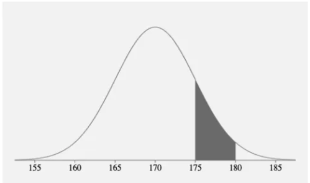

> Likelihood is the flip-side perspective: you start with observed data and ask, “Given that I saw this data, how plausible is a particular choice of model parameters?” The likelihood isn’t itself a probability distribution over parameters (it doesn’t sum or integrate to one), but rather a scoring function that tells you which parameter values make the observed data most “likely.” For a probability density function the likelihood is the y axis value for some given x axis value.

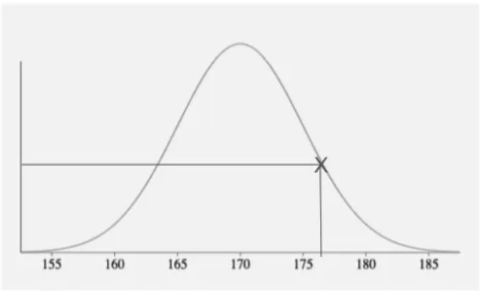

> *Graphical representation of likelihood for probability density function*

> NOTE: The probability density function and the likelihood function are the same things, just that probability density function is a function of data while likelihood function is a function of parameters.

**2.2 Bayes Theorem:**

> At its heart, Bayes’ theorem is a way to **update** our beliefs about an unknown quantity θ once we observe some data x. In its most common form (for discrete or continuous alike) it’s written as:

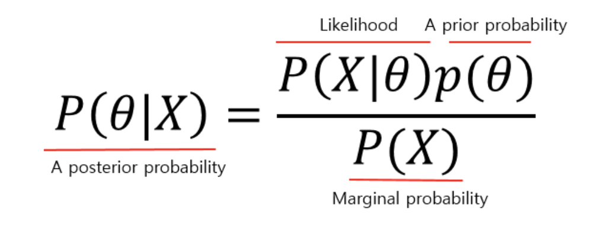

Each of the four pieces has a name and a distinct role:

## **1. Prior — P(θ)**

- Meaning: Your initial belief about the parameter θ before seeing the data.
- Properties: A probability distribution over θ and encodes any background knowledge or assumptions.

## **2. Likelihood — P(x∣θ)**

- Meaning: The probability (or probability density) of observing the data x given a particular θ.
- Properties: Tells you which values of θ make the observed data most probable.
- Key point: As a function of θ, P(x∣θ) is the likelihood function L(θ∣x)

## **3. Evidence (Marginal Likelihood) — P(x)**

- Meaning: The probability of observing the data x averaged over all possible θ

> $P(x)\ = \ \int_{}^{}\ p(x|\theta)\ p(\theta)\ d\theta$ or $\sum_{\theta}^{}\ if\ discrete\$
- Properties: Acts as a normalizing constant so that posteriors sum (or integrate) to 1.

## **4. Posterior — P(θ∣x)**

- Meaning: Your updated belief about θ after observing the data x.
- Properties :A full probability distribution over θ and reflects both your background belief and the information in the data.

**2.3 Gaussian Distribution**:

> Normal distribution, also known as the Gaussian distribution, is a continuous probability distribution that is symmetric about the mean, depicting that data near the mean are more frequent in occurrence than data far from the mean.

> Normal Distribution Characteristics:
- Symmetry: The normal distribution is symmetric around its mean. This means the left side of the distribution mirrors the right side.
- Mean, Median, and Mode: In a normal distribution, the mean, median, and mode are all equal and located at the center of the distribution.
- Bell-shaped Curve: The curve is bell-shaped, indicating that most of the observations cluster around the central peak and the probabilities for values further away from the mean taper off equally in both directions.
- Standard Deviation: The spread of the distribution is determined by the standard deviation. About 68% of the data falls within one standard deviation of the mean, 95% within two standard deviations, and 99.7% within three standard deviations.

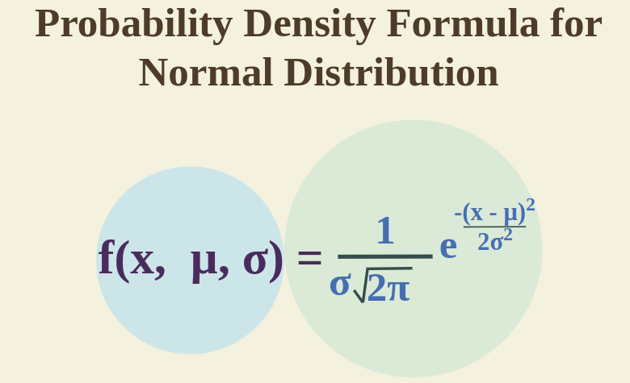

3. **The Gaussian NB model:**

> Now that the prerequisites of the model are clear so now we look into the actual model. On a basic level what we do is we calculate the mean and the standard deviation of the given dataset for each feature, using these we form a gaussian distribution for each feature. Now we consider a prior distribution probability for each class based on the initial training set and then these are updated based on bayes theorem using conditional likelihood for each feature with respect to each class.

> **3.1 Derivation of the classifier:**

> Now we start with a vector $x\ = \ (\ x1,\ x2\ ,\ ......\ xn)\$which is the feature vector and a collection of classes $y\ \in \ \{\ 1,\ 2,\ 3\ ....\ k\ \}$
- So by bayes theorem:

> $P(\ Y = y\ |\ x\ )\ = \ (P(\ x\ |\ Y = y)\ P(\ Y = y))/$ $P(x)\ \ \ \propto \ \ P(\ x\ |\ Y = y)\ P(\ Y = y)\ \ \$

> Here we are ignoring the evidence term since that is common to all features.
- Under the naive assumption:

> Here $\sigma i$ represents the standard deviation of the ith feature and likewise for mean and x
- To Avoid underflow, we usually use the log posterior (discriminant function)

> $g(x)\ = \ log\ P(\ x\ |\ Y = y)\ + \ log\ P(Y = y)$

> $g(x) = \ - 1/2\ \sum_{i = 1}^{n}log(\ 2\pi\sigma i^{2})\ \ - 1/2\sum_{i = 1}^{d}(xi - \mu i)/2\sigma i^{2}\ + log\ P(Y = y)\$
- Now the final classifier equation looks like this, for this we take the max value for which ever $y$ it gives the maximum value of g(x).

> $y'\ = \ arg\ max\ \lbrack - 1/2\ \sum_{i = 1}^{n}log(\ 2\pi\sigma i^{2})\ \ - 1/2\sum_{i = 1}^{d}(xi - \mu i)/2\sigma i^{2}\ + log\ P(Y = y)\rbrack\$

> Thus y’ becomes the class to which the features belong to after the classification.
- Now a special condition is that when each feature has the same standard deviation across all the classes, we get a linear decision boundary

> Here the $- 1/2\ \sum_{i = 1}^{n}log(\ 2\pi\sigma i^{2})\ \$becomes a constant so the final classifier becomes

> $y'\ = \ \ arg\ max\ \lbrack\ - 1/2\sum_{i = 1}^{d}(xi - \mu i)/2\sigma i^{2}\ + log\ P(Y = y)\rbrack$

> **3.2 Example**:

> Now we take a look at a concrete spam- no spam example using two features and a gaussian NB model.
- Now we use two features here x1 and x2 with these representing average word length and the occurrence of word “free” in the document.
- Our dataset looks like this:

| Email text | class | **x1** | **x2** |
| --- | --- | --- | --- |
| “Win a free vacation now” | Spam | 4 | 1.0 |
| “Lowest prices—**free** shipping today!” | Spam | 5.2 | 0.8 |
| “Hi team, please review the meeting notes” | No spam | 5.5 | 0.0 |
| “Let’s catch up for coffee tomorrow” | No spam | 5.8 | 0.0 |

> **Priors**: p(spam) = 0.5 and p(no spam) =0.5
- Estimating the mean and the variance of each of the two features:

> Spam ( 2 samples):

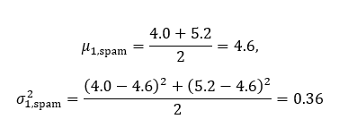

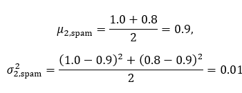

No spam ( 2 samples):

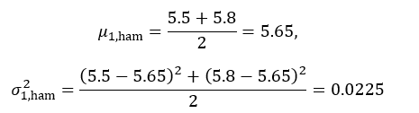

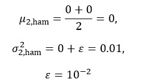

We have added a tiny smoothing for the standard deviation of the second feature for no spam class

- Classifying a new mail now:

> “Get your **free** ebook—download now!” is our new mail

> Compute its features:

> x1= average word length ≈ 4.3

> x2= “free” appears once in 6 words →1/6≈0.167

> Now we for the discriminant for each class using the equation:

**4. Additional Material**:

Now for additional materials you can refer the following links:

1. Geeksforgeeks article on Gaussian NB model: https://www.geeksforgeeks.org/machine-learning/gaussian-naive-bayes/
2. Scikit Learn documentation on Gaussian NB model for implementation:https://scikit-learn.org/stable/modules/generated/sklearn.naive_bayes.GaussianNB.html